# Griffintown, from a gift of the machine age to a water wheel in the growth machine

Camille Forest

The jurisdictional landscape of water management services in Canada is self-conflicting, where all levels of government have responsibilities that depend on actions by other levels of government. In Canada, the federal government is responsible for keeping major waterways clear and maintaining of fisheries through ensuring clean fish habitats (Environment and Climate Change Canada, 2016). Municipalities are responsible for storm water overflow, and the provinces are responsible for most other water quality and management services; all of which can impact fisheries. However, the province of Quebec has both historically and currently delegated maintaining water quality, including storm and wastewater, to municipalities. The distribution of responsibilities across levels of government has historically resulted in jurisdictional gridlock from the federal government and provinces (Boone, 1996). This case study illustrates how in the absence of action by federal and provincial governments, the most local levels of government and community governance define their relationship with water in the city.

Griffintown is a neighbourhood in Montreal with complex and turbulent history of neglect by local governance, and this essay will tease out how Griffintown’s social and governance history can be defined through the politics of water management. In his *History of Montreal*, Steven Leacock describes Griffintown as:

*“…the area west of McGill Street, between the new railway and the new canal. This wretched area, whose tumbled, shabby houses mock at the wealth of Montreal, was the first of our industrial slums, the gift of the machine age…” and “the unhappy settlement of Griffintown…built on low land for working class, who must take what they can get…”*

As Leacock noted, the origin of the neighbourhood was as an industrial slum home to mainly recent immigrant Irish factory workers and a neighbourhood subjected to devastating seasonal floods. The mostly low-income, racialized residents, with poor sanitation service provision and regular flooding combined to create the conditions for Griffintown to be the most disease-ridden neighbourhood in Montreal (Home-Douglas, 2007). However, this ‘slum’ was important to the early growth of Montreal through its function as the industrial heart of the city, providing conditions for its economic growth during the Industrial Revolution.

The governance of present-day Griffintown bears little resemblance to this neglect and stigma, where developer speculation dominates its landscape. However, the lack of a timely comprehensive planning process by the city has hindered the ability to properly plan for water in the neighbourhood. Further, the city’s generous granting of high-rise re-zonings indicate the neighbourhood may be continuing to experience inadequate, profit-driven governance. The articulation of the city as a growth machine, meant to churn out ever-increasing net income, is a poignant analogy for the recent development of Griffintown (Logan & Molotch, 2007). This politics of growth applies to water management policy as much as any realm of urban governance. The history of local governance and water in Griffintown illustrates Logan and Moloch’s (2007) argument that planning which encourages growth without first questioning whether there is a social desire for growth will result in a “bias in favour of the speculators and against the working class” and against community good in this case. Herein, the evolution of local politics and urban governance in Griffintown, from an urban slum to a developer’s dream, has been defined by neglecting working class residents and this neglect is mirrored in the history of the neighbourhood’s water management.

### From the Nazareth Fief to the Birth of Griffintown

Griffintown was an undesirable place for settlement in Montreal’s early development due to its position on low-lying, marshy land. South of Montreal’s original Port, now known as the Old Port, it was originally a marshy fiefdom called Nazareth Fief, and unofficially referred to as *Le Grange des Pauvres* (Griffinworks, n/a). The fortification of early Montreal, then known as Ville Marie, resulted in large stone walls cutting Nazareth Fief off from the budding city. When a fire destroyed half of Ville Marie in 1721 and an ordinance was issued that all buildings inside Ville Marie must be constructed by masonry. Poor residents who could only afford to build their homes with wood began to build Montreal’s first suburb in the Nazareth fief (Mofarrahi, 2009). When Ville Marie’s fortification walls came down by 1817, the Nazareth Fief became integrated into Montreal’s governance and receiving services such as roads and beginning to contribute to the city’s economy (Marsan, 1981).

Irish immigrants, pushed to emigrate by the Potato Famine and land reforms, continued to settle in Griffintown looking for work, the neighbourhood became a key economic driver of early Montreal. This was propelled by large construction projects in the area, such as the Lachine Canal, Grand Trunk Railroad depot and the Victoria bridge, as well as the heavy industry located in the neighbourhood which employed 4000 men, women, and children from the neighbourhood (Mofarrahi, 2009; Solonysznyj, 1988). Griffintown’s industrial operations led Montreal’s Industrial Revolution due to the sheer number of industrial complexes housed in the neighbourhood and because of its proximity to the construction of the Lachine Canal (Mofarrahi, 2009). The Lachine Canal is cited as the most significant event of Montreal’s Industrial Revolution, through allowing shipping to bypass the Lachine rapids and carry manufactured goods West, into upper Canada. (Home-Douglas, 2017; Mofarrahi, 2009).

Once the construction of the Lachine Canal finished in 1825, Griffintown’s importance as an economic engine for Montreal was cemented; by 1860 more than 50 factories were operating in Griffintown (Mofarrahi, 2009). Despite the city providing basic utilities to the neighbourhood between 1880-1915, Montreal as a city was known for some of the worst public health conditions in any industrialized nation during this period, with poor garbage removal and poor access to clean drinking water (Ames,1972). Griffintown was the neighbourhood in Montreal hardest hit by disease and infant mortality. Sanitation challenges were exacerbated for the residents of Griffintown compared to the rest of the city, because many families lived in overcrowded homes, only half had toilets, and they all faced persistent seasonal flooding.

Spring floods during this period were primarily caused by ice jams and snow melt raising water levels in the St. Lawrence (Hanna, 2007). Inundation of homes and factories worsened public health conditions and likely contributed to the poorest public health outcomes of the city being clustered in the Griffintown area (Mofarrahi, 2009; Hanna, 2007). Flooding also had a social impact on the community: surviving the perennial flooding bonded the residents and created a resilient spirit among them where people made “the best of a bad situation by boating around serenading one another in song accompanied by guitars, fiddles and ‘music boxes.’ This helped them to forget the big task that lay ahead, the yearly ‘clean up’ after the waters receded” (Gubbay, 1981). Without any formal assistance from the local government, the community was solely responsible for dealing with its problems with water.

[figure not shown]

Figure 1. Flood, Bonaventure Depot, Montreal, QC, 1886. by George Charles Arless. Source: the McCord Museum.

The worst flood on record in Montreal occurred in 1886, and although Griffintown was accustomed to the multiple feet of water inundating their neighbourhood, this flood was considered disastrous and costly because it also affected the Port and caused the temporary closing of factories in Griffintown (Ref. Figure 1). The flood of 1886 is a key reference for the historical high point of water in the city of Montreal, and notable for the flooding of wealthy neighbourhoods at higher elevations, which caught the attention and passion the municipal level of government. During the 1880’s & 1890’s, the federal and provincial government had yet to formally assign responsibility for water management to any level government, and thus local communities and the City of Montreal were on their own to solve any urban water challenges.

Known as ‘a mayor for the port,’ Mayor Raymond Préfontaine responded to cost of these seasonal floods through commissioning the construction of a floodwall in 1899 (Ville de Montreal, nd). The wall, which is now part of the Cité-du-Havre, stands 1,561 meters long and 56 cm higher than the highest point to the 1886’ flood (Montpetit, 2017). This floodwall provided protection of the economic heart of the city: the Port and the Lachine Canal. However, while the floodwall was pitched in 1899 as the solution to Montreal’s flooding problem – the slogan for the wall was ‘there will be no more flooding’ – this has not proved to be entirely true (Ville de Montreal, N/A).

### Griffintown as a Ghost Town

Governance concerns about flooding in Griffintown dissipated with the departure of most residents. Instead, the municipal government focused on making sure the land served a purpose to Montreal’s urban growth through the 1970s and 1980s, through developing the now-sparsely populated area into a concrete matrix of industrial complexes, complimented by a highway.

With the opening of the St Lawrence seaway in 1959, the Lachine Canal, once a key tool for the economic development strategy of Montreal, became obsolete (Home-Douglas,2017). After the closing of the canal, Griffintown’s fortunes as a neighbourhood worsened – the strategic value of its land and industry was diminished without the Lachine Canal as a crucial shipping route. Despite the reduction in flooding, living conditions remained relatively poor in the neighbourhood during the first half of the 20<sup>th</sup> century.

As industry began leaving the neighbourhood in the 1930’s and 1940’s, a series of local governance actions accelerated the decline of the neighbourhood (Mofarrahi, 2009). An area of shacks, abandoned factories and community centres stood as relics from the once booming industrial neighbourhood. The land was slowly cleared of residents, and then cultural heritage.

In 1963, Montréal Mayor Jean Drapeau zoned the entire neighbourhood as industrial, prohibiting community development or rebuilding in the area (Home-Douglas, 2017). At this time, Griffintown’s remaining residents also experienced the building of the Bonaventure Expressway through their community, decimating factories and homes and uprooting almost all remaining residents (Home-Douglas, 2017). In the late 60’s, Griffintown’s population dropped to fewer than six hundred people, as the governance strategy for the neighbourhood seemed to be intentionally clearing the area of any residential or cultural presence (Home-Douglas, 2017).

### The Revival of Both Griffintown and Neglected Flood Risks

While Mayor Préfontaine addressed seasonal floods for Old Port and Griffintown in 1899, the West Island and most municipalities in the *Communauté Métropolitaine de Montréal* (CMM) continue to struggle with the spring-time floods to this day. However, due to the increasing frequency and intensity of large rainfall events, as well as less predictable weather patterns, flooding has re-emerged in recent years as an important planning consideration for Montreal’s downtown neighbourhoods. One poignant example of this is the Montreal flood of 1987 where 100 mm of rain fell within an hour, flooding expressways with nearly 4m of water, backing up the sewer system into approximately 40,000 homes and businesses, closing the subway system and killing two people (Public Safety Canada, 2013).

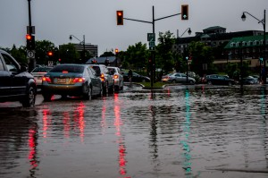

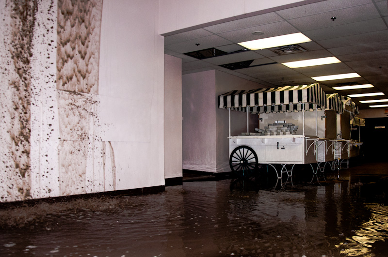

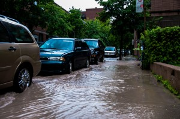

Figure 2. Flash flood in Milton-Parc neighbourhood of Montreal, 2012. This flooding of storm water with nowhere to go in a network of impervious surfaces is expected to increase with climate change (IPCC, 2019), and the planning of Griffintown. Source: Montreal in Pictures, 2012 (https://montrealinpictures.com/montreal-image-photo-gallery/may-2012/)

By 1990, Montreal had grown both in population and sprawl enough that post-industrial Griffintown became valuable land to the city for development. The downtown had expanded enough that Griffintown was then the last undeveloped neighbourhood adjacent to downtown. The city’s ambitions for Griffintown in the 1990s lacked a comprehensive planning process and consisted of the city selling land to developers and approving numerous rezoning applications for high rise developments. The City of Montreal was looking for the neighbourhood to provide an economic boost to the city just as it had back in the early 19<sup>th</sup> Century. This time, however, through gentrification.

Following the re-zoning of a number of significant parcels and budding gentrification in the area, the square-foot price of land in Griffintown increased from 8$-20$/sqft in 2005 to 300$/sqft in 2015 (Friede, 2015). Most recently, community backlash from the lack of community services and amenities provision, such as greenspace, transportation, schools, etc., has prompted a shift in the branding and apparent focus of Griffintown’s redevelopment.

The newest planning programs highlight sustainable community development as well as economic growth in the region (FIX-INNO, 2020; Lemieux, 2018). The neglect of Griffintown’s community interests in its recent planning is now attempting to be rectified by integrating proper water management techniques for the community, such as the areas first permeable pavement pedestrian street in Montreal, which allows for on-site absorption and filtration of overflow water (FIX-INNO, 2020) and a large retention basin connected to the city’s storm and wastewater pipes, in Marie Griffin Park (Lemieux, 2018). This retention basin will be an overflow catchment of water for the city’s wastewater system, which hopefully reduces the risk of a sewer system back up, as occurred in the flood of 1987’.

However, the initial lack of comprehensive planning has hindered the city’s ability to plan for water in the neighbourhood in some key ways. It is now much more expensive for the city to acquire land for public greenspace and therefore their ability to plan a connective network of green urban infrastructure to optimise the hydrology of the area has been significantly hindered.

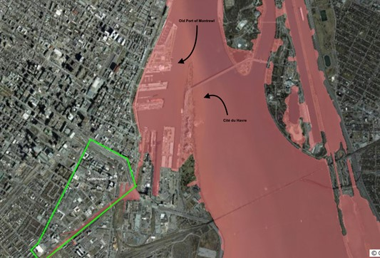

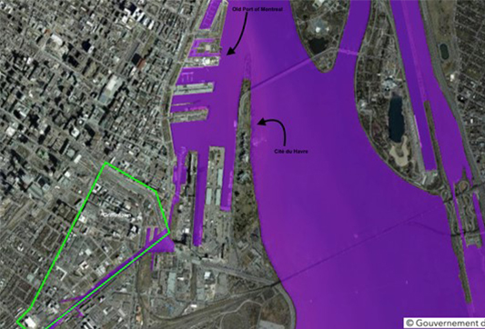

Figure 3. Left: Initial flood map released by the Province of Quebec on July 10th 2019. Right: Updated map of flood risk zones released on July 15th 2019.

The recent emergence of water management as a top priority for Montreal and Quebec planners is likely because of the increasing cost of flooding to urban infrastructure. This is a direct threat to a neoliberal, profit-driven logic that requires growth of the physical and economic city. In 2019, devastating flooding hit the West Island and Laval, prompting the Province of Quebec to ban reconstruction of homes damaged by the flood and new developments within the most recent flood line (Anhoury, 2019).

When the province released its map of flood risk zones (Ref. Figure 3 – left), there were outcries from developers whose land was within flood zone boundaries. The province’s new regulations were jeopardizing developer investments and profits. The developer complaints, based on how water levels were estimated, led to the reconfiguration of flood zones to cover less area (as shown in Figure 3 – right). Comprehensive records and maps of flood risk are managed by provincial and federal agencies, and primarily address flooding from large waterways. For example, the flash flood of 2012 (Ref. Figure 2) is not mentioned in the Canadian public health database for significant floods (Public Safety Canada, 2013). This database illustrates a key influence the federal government has over flood-related planning decisions that did not exist during Griffintown’s early history. Specifically, which floods are tracked and used to inform planning decisions may tell one story and funnel funding into a certain type of flood mitigation without a comprehensive picture of all the floods that are occurring in Montreal.

Another new role of the federal government in flood mitigation and planning for Montreal has been in the form of funding. In 2019, Prime Minister Trudeau announced 50$ million for wetland protection and upgrading pump stations and valves on the West Island (Prime Minister’s Office, 2019). Both the federal funding of flood infrastructure and the provincial flood mapping that make up more modern urban governance of flood mitigation rely heavily on local governance dynamics of developer interests and municipal planning of projects.

Also in 2019, the CMM released a comprehensive risk assessment guide for the 82 municipalities making up the agglomeration (CMM, 2019). At the level of the municipal agglomeration, planning processes that concern flooding result in guiding principles for individual municipal and community decision makers. Thus, the modern state of urban governance of water in Griffintown is still dominated by the community’s relationship with the city. Both federal and provincial flood data is myopically focused on flooding from the St. Lawrence, as illustrated by the lack of comprehensive data in the Canadian Disaster Database and that Quebec’s flood zone mapping is based solely on the 2019 spring flood from the St. Lawrence (and subsequently walked back to appease developer interests). Therefore, the primary form of flooding that effects Griffintown now, flooding from storm water overflow, is poorly studied, and mapped, meaning funding and planning for this risk will likely be lacking in the future.

### Conclusion

The future of planning for water flooding in Griffintown is at a crossroads. There is significant public pressure to prioritize community needs for the first time in Griffintown’s history, which has led to some flooding mitigation infrastructure. However, the lack of data for flooding, specifically from storm water, in government databases and maps biases municipalities to neglect the flooding risks that threaten Griffintown. Given developer interest in developing the area this is unlikely to change without specific community demands.

This case study overviews a long history of governance driven by a logic of growth, which has left community well-being out of Griffintown’s planning process. Research showing that storm-water flooding is also a large future potential cost of flooding and community advocacy for climate resilient development will be a key to effective planning processes concerned with water management in Griffintown in the future.

### Bibliography

- Ames, H. B. (1972). *The city below the hill*. Toronto, ON: Franklin Classics Trade Press.
- Anhoury, M. (2019, July 16). Quebec releases updated map of flood zones. *Montreal Gazette*. Retrieved December 11, 2020, from https://montrealgazette.com/news/quebec/quebec-releases-updated-map-of-flood-zones
- Boone, C. G. (1996). Language Politics and Flood Control in Nineteenth Century Montreal. *Environmental History,* *1*(3), 70-85. doi:10.2307/3985157
- CMM. (2019). *Rapport de consultation sur la proposition d’un règlement relatif aux territoires à risque d’inondatoin* (pp. 1-34) (Canada, Communauté métropolitaine de Montréal, Planning). Montreal, QC.
- Environment and Climate Change Canada. (2016, January 07). Water governance and legislation: Shared responsibility. Retrieved December 15, 2020, from https://www.canada.ca/en/environment-climate-change/services/water-overview/governance-legislation/shared-responsibility.html
- FNX-INNOV. (2020, July 22). A breath of fresh air for the Griffintown neighbourhood. Retrieved December 15, 2020, from https://fnx-innov.com/a-breath-of-fresh-air-for-the-griffintown-neighbourhood/
- Friede, E. (2015, July 25). Too little, too late? Urban plan for Griffintown came after the fact. *Montreal Gazette*. Retrieved December 9, 2020, from https://montrealgazette.com/business/too-little-too-late-urban-plan-for-griffintown-came-after-the-fact
- Griffinworks. (n/a). Griffintown – Timeline. Retrieved December 15, 2020, from https://griffinworks.ca/griffintown-history/
- Gubbay, A. (1981). *Montreal: The mountain and the river*. Montreal, QC: Livres Trillium.
- Hanna, D. B. (2007). *GRIFFINTOWN: SON HISTOIRE ET SON CADRE BÂTI*. Montrreal, D: Ville de Montréal.http://griffintown.org/history/docs/docGriffintownHistoireCadreBati.pdf
- Home-Douglas, P. (2017, May). Montréal’s Griffintown Reborn. *Canada’s History*. https://www.canadashistory.ca/explore/travel/montreal-s-griffintown-reborn
- IPCC (Intergovernmental Panel on Climate Change). 2019. Global Warming of 1.5 ºC. UNEP.
- Lemieux, A. (2018). Ouvrage de rétention William Séance d’Information Aux Citoyens (pp. 1-38) (Canada, Service de l’eau, Irection de l’épuration des eaux usées). Montreal, Quebec: Ville de Montréal.
- Leacock, S. B. (1945). *Montreal, seaport and city*. Toronto, ON: McClelland & Stewart.
- Logan, J. and Molotch, H. (2007). The City as a Growth Machine. In Urban Fortunes: The Political Economy of Place. Berkeley and Los Angeles: University of California Press, 50-98.
- Marsan, J. C. (1981) Montreal in Evolution: Historical analysis of the development of Montreal’s architecture and urban environment. Montreal: McGill Queen’s University Press.
- Mofarrahi, G. (2009). *Griffintown*. Montreal, QC: McGill University. doi:http://griffintown.org/history/docs/docGriffintownGolrooMoffarahi.pdf
- Montpetit, J. (2017, May 14). A haggard mayor and everyday heroes: Tales from Montreal’s 1886 flood. *CBC*. Retrieved December 9, 2020, from https://www.cbc.ca/news/canada/montreal/montreal-flood-1886-quebec-1.4112735
- Prime Minister’s Office. (2019, August). New investments to protect Montréal against floods and help create the largest urban park in Canada. Retrieved December 15, 2020, from https://pm.gc.ca/en/news/news-releases/2019/08/21/new-investments-protect-montreal-against-floods-and-help-create
- Public Safety Canada. (2013). Retrieved 2020, from https://cdd.publicsafety.gc.ca/rslts-eng.aspx?cultureCode=en-Ca&provinces=11&eventTypes=%27FL%27&eventStartDate=%2718250101%27%2c%2720131231%27&normalizedCostYear=2013.
- Solonysznyj, P. (1988) Residential Persistence in an Ethnic Working-Class Community: St. Ann’s Ward, Montreal, 1871 to 1891. Master’s essay (History). Montreal, Quebec: Concordia University.
- Ville de Montreal. (n/a). Raymond Préfontaine’s accomplishments at the municipal level. Retrieved December 13, 2020, from http://www2.ville.montreal.qc.ca/archives/democratie/democratie_fr/media/documents/apprentis/journaux/prefontaine_en.pdf